# Motor Trend Project: MPG Analysis

Ambrosio Q. Tria

## Preface

This is the project for the Coursera/ Johns Hopkins Bloomberg School of Public Health course, Regression Models. It assumes working for Motor Trend, using the built in data set `mtcars` to answer hypothetical questions with analysis and regression modeling. PDF Report layout comprises of Table of Contents (1 page), Main Body (2 pages), and Appendix (5 pages).

## Executive Summary

In order to provide empirical evidence for Motor Trend, this report presents the analysis of miles per gallon (MPG) on a select collection of cars. The outcome variable representing MPG will be analyzed against other variables found in the dataset `mtcars` using exploratory data analysis and regression modeling. The analysis will address two areas of concern:

Supporting figures for the analysis can be found in the Appendix section of this report. For convenience throughout the main body of the report, links have been created for easier navigation to the supporting figures in the appendix.

## Exploratory Data Analysis

Looking at the structure {figure 1} of the dataset `mtcars`, we can see that it is comprised of 32 observations on 11 variables, where all variables are numeric. Of the variables listed and their descriptions {figure 2}, the variable `am` describes the car’s transmission type - boolean values of [1, 0]; where 0 is for automatic transmission, and 1 is for manual transmission per the description {figure 2} of `am`.

We will copy the original data into a new data frame named `mtcars2` where we will assign names to the numerical values of `am` in the observations. This will assist with readability in the plots.

## Regression Modeling

### SLR modeling

Let’s take a quick look at fitting a regression model on `mpg` as the outcome and the transmission type (`am`) as the regressor. We will use a simple linear regression (SLR) model. Its plot {figure 5} shows that manual transmission vehicles have better `mpg` than automatic vehicles. This can be misleading, because as we saw in our exploratory data analysis, there are other variables in the dataset that can potentially impact `mpg`, which is not accounted for in this simple plot.

Finally, let’s confirm if other variables in the data set impact `mpg`. Taking a look at the SLR of `mpg` versus horsepower (`hp`), you can see a linear decrease for `mpg` as horsepower increases for both automatic and manual transmissions, opposite than what we saw in the SLR for `mpg` versus Transmission Type. Its residual plot is more reasonable than what we saw before; however, there seems to be a secondary linear pattern showing for both automatic and manual transmission, suggesting a relationship with one or more other variables in the dataset. You can see this in {figure 6}.

From these results, we’ve confirmed that other variables in the data set do have an impact on `mpg`, as well as on each other. Therefore, we will need to apply a different regression model to the data set. Before we do, we will assess which variables to include and which to exclude.

### Multivariate regression modeling

We will use a multivariate linear regression model on the dataset. The multivariate regression summary of `mpg` vs all the other variables {figure 7} gives us the coefficients to interpret the impact of each variable in the dataset on `mpg`, as they are influenced by every other variable held at that particular time.

Based on coefficient significance and correlation strength, we will create a multivariate model of `mpg` vs `am` + `wt` + `disp` + `cyl` as the model to answer our questions. Let’s confirm this final model.

We have our final regression summary {figure 9} and visualization plot {figure 10} of our selected model.

## Conclusion

We should be clear that the dataset `mtcars` is very limited with number of observations and randomness, and is aged. It is a data source from 1974.

Note: This report was authored in R Markdown and compiled to pdf using pdflatex (via knitr)[^1]. Figure 3 and figure 4 were omitted due to space constraints.

# Appendix

All supporting figures can be found in this appendix. For convenience, links have been created for easier navigation back to the main body of the report. Note that captions for the figures have been left out because of the linked figure titles.

## Figure 1: Structure of the dataset MTCARS

```
## 'data.frame':    32 obs. of  11 variables:
##  $ mpg : num  21 21 22.8 21.4 18.7 18.1 14.3 24.4 22.8 19.2 ...
##  $ cyl : num  6 6 4 6 8 6 8 4 4 6 ...
##  $ disp: num  160 160 108 258 360 ...
##  $ hp  : num  110 110 93 110 175 105 245 62 95 123 ...
##  $ drat: num  3.9 3.9 3.85 3.08 3.15 2.76 3.21 3.69 3.92 3.92 ...
##  $ wt  : num  2.62 2.88 2.32 3.21 3.44 ...
##  $ qsec: num  16.5 17 18.6 19.4 17 ...
##  $ vs  : num  0 0 1 1 0 1 0 1 1 1 ...
##  $ am  : num  1 1 1 0 0 0 0 0 0 0 ...
##  $ gear: num  4 4 4 3 3 3 3 4 4 4 ...
##  $ carb: num  4 4 1 1 2 1 4 2 2 4 ...
```

Executive Summary | Exploratory Data Analysis | Regression Modeling | Conclusion

## Figure 2: Dataset Variable Description

```
##    VARIABLE                              DESCRIPTION
## 1       mpg                        Miles/(US) gallon
## 2       cyl                      Number of cylinders
## 3      disp                    Displacement (cu.in.)
## 4        hp                         Gross horsepower
## 5      drat                          Rear axle ratio
## 6        wt                         Weight (lb/1000)
## 7      qsec                            1/4 mile time
## 8        vs                                      V/S
## 9        am Transmission (0 = automatic, 1 = manual)
## 10     gear                  Number of forward gears
## 11     carb                    Number of carburetors
```

Executive Summary | Exploratory Data Analysis | Regression Modeling | Conclusion

## Figure 5: SLR of MPG vs Transmission Type, and its Residual Plot

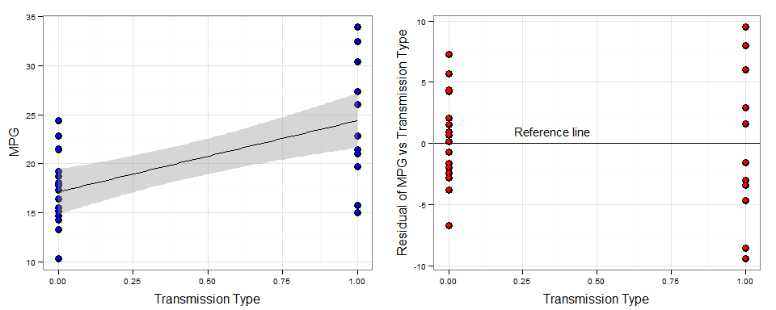

Executive Summary | Exploratory Data Analysis | Regression Modeling | Conclusion

## Figure 6: SLR of MPG vs Horsepower for Transmission Types, and its Residual Plot

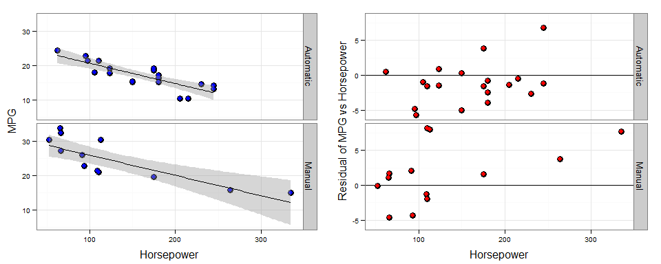

Executive Summary | Exploratory Data Analysis | Regression Modeling | Conclusion

## Figure 7: Regression Summary of MPG vs all other variables

```
##
## Call:
## lm(formula = mpg ~ ., data = mtcars)
##
## Residuals:
##     Min      1Q  Median      3Q     Max
## -3.4506 -1.6044 -0.1196  1.2193  4.6271
##
## Coefficients:
##             Estimate Std. Error t value Pr(>|t|)
## (Intercept) 12.30337   18.71788   0.657   0.5181
## cyl         -0.11144    1.04502  -0.107   0.9161
## disp         0.01334    0.01786   0.747   0.4635
## hp          -0.02148    0.02177  -0.987   0.3350
## drat         0.78711    1.63537   0.481   0.6353
## wt          -3.71530    1.89441  -1.961   0.0633 .
## qsec         0.82104    0.73084   1.123   0.2739
## vs           0.31776    2.10451   0.151   0.8814
## am           2.52023    2.05665   1.225   0.2340
## gear         0.65541    1.49326   0.439   0.6652
## carb        -0.19942    0.82875  -0.241   0.8122
## ---
## Signif. codes:  0 '***' 0.001 '**' 0.01 '*' 0.05 '.' 0.1 ' ' 1
##
## Residual standard error: 2.65 on 21 degrees of freedom
## Multiple R-squared:  0.869,  Adjusted R-squared:  0.8066
## F-statistic: 13.93 on 10 and 21 DF,  p-value: 3.793e-07
```

Executive Summary | Exploratory Data Analysis | Regression Modeling | Conclusion

## Figure 9: Regression Summary of MPG vs Select Variables

```
##
## Call:
## lm(formula = mpg ~ am + wt + disp + cyl, data = mtcars)
##
## Residuals:
##    Min     1Q Median     3Q    Max
## -4.318 -1.362 -0.479  1.354  6.059
##
## Coefficients:
##              Estimate Std. Error t value Pr(>|t|)
## (Intercept) 40.898313   3.601540  11.356 8.68e-12 ***
## am           0.129066   1.321512   0.098  0.92292
## wt          -3.583425   1.186504  -3.020  0.00547 **
## disp         0.007404   0.012081   0.613  0.54509
## cyl         -1.784173   0.618192  -2.886  0.00758 **
## ---
## Signif. codes:  0 '***' 0.001 '**' 0.01 '*' 0.05 '.' 0.1 ' ' 1
##
## Residual standard error: 2.642 on 27 degrees of freedom
## Multiple R-squared:  0.8327, Adjusted R-squared:  0.8079
## F-statistic: 33.59 on 4 and 27 DF,  p-value: 4.038e-10
```

Executive Summary | Exploratory Data Analysis | Regression Modeling | Conclusion

## Figure 10: Visualization of Regression Summary of MPG

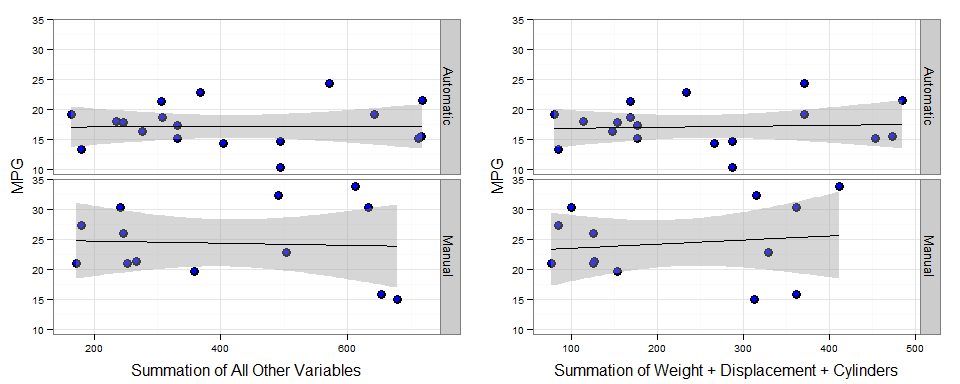

Executive Summary | Exploratory Data Analysis | Regression Modeling | Conclusion

## Figure 11: ANOVA Table 1, Our Selected Model Test

```
## Analysis of Variance Table
##
## Model 1: mpg ~ am
## Model 2: mpg ~ am + wt
## Model 3: mpg ~ am + wt + disp + cyl
##   Res.Df    RSS Df Sum of Sq       F    Pr(>F)
## 1     30 720.90
## 2     29 278.32  1    442.58 63.4179 1.469e-08 ***
## 3     27 188.43  2     89.89  6.4406  0.005165 **
## ---
## Signif. codes:  0 '***' 0.001 '**' 0.01 '*' 0.05 '.' 0.1 ' ' 1
```

Executive Summary | Exploratory Data Analysis | Regression Modeling | Conclusion

```
## Analysis of Variance Table
##
## Model 1: mpg ~ am
## Model 2: mpg ~ am + wt
## Model 3: mpg ~ am + wt + disp + cyl
## Model 4: mpg ~ wt + disp + cyl + qsec
##   Res.Df    RSS Df Sum of Sq       F    Pr(>F)
## 1     30 720.90
## 2     29 278.32  1    442.58 63.4179 1.469e-08 ***
## 3     27 188.43  2     89.89  6.4406  0.005165 **
## 4     27 175.67  0     12.76
## ---
## Signif. codes:  0 '***' 0.001 '**' 0.01 '*' 0.05 '.' 0.1 ' ' 1
```

Executive Summary | Exploratory Data Analysis | Regression Modeling | Conclusion

```
## Analysis of Variance Table
##
## Model 1: mpg ~ am
## Model 2: mpg ~ am + wt
## Model 3: mpg ~ am + wt + disp + cyl
## Model 4: mpg ~ wt + disp + cyl + qsec
## Model 5: mpg ~ wt + disp + cyl + hp
##   Res.Df    RSS Df Sum of Sq       F    Pr(>F)
## 1     30 720.90
## 2     29 278.32  1    442.58 63.4179 1.469e-08 ***
## 3     27 188.43  2     89.89  6.4406  0.005165 **
## 4     27 175.67  0     12.76
## 5     27 170.44  0      5.22
## ---
## Signif. codes:  0 '***' 0.001 '**' 0.01 '*' 0.05 '.' 0.1 ' ' 1
```

Executive Summary | Exploratory Data Analysis | Regression Modeling | Conclusion

[^1]: To view the raw source and for reproducibility, please visit my Github [repository](https://github.com/AmbroseT/RegressionModels)